# Lab

## SQL and Data Frames

Alessandro D. Gagliardi

# Enron

### Download the sample database at: [tinyurl.com/enron-db](https://github.com/eklypse/GA_DS_SF_2014_01/raw/master/enron.db)

`pip install ipython-sql`  
**for sql magic**

```python
%load_ext sql
```

```python
%%bash
sqlite3 enron.db .tables
```

```
Employee          EmployeeWithVars  MessageBase       RecipientBase
EmployeeBase      Message           Recipient
```

We only care about the `*Base` tables:

- EmployeeBase
- MessageBase
- RecipientBase

(The other tables are derived from those. We don't need them for this exercise.)

```python
%%sql sqlite:///enron.db
SELECT * FROM EmployeeBase LIMIT 5
```

```
Done.
```

| eid | name | department | longdepartment | title | gender | seniority |
| --- | --- | --- | --- | --- | --- | --- |
| 1 | John Arnold | Trading | ENA Gas Financial | VP Trading | Male | Senior |
| 2 | Harry Arora | Trading | ENA East Power | VP Trading | Male | Senior |
| 3 | Robert Badeer | Trading | ENA West Power | Mgr Trading | Male | Junior |
| 4 | Susan Bailey | Legal | ENA Legal | Specialist Legal | Female | Junior |
| 5 | Eric Bass | Trading | ENA Gas Texas | Trader | Male | Junior |

```python
%%sql sqlite:///enron.db
SELECT * FROM MessageBase LIMIT 5
```

```
Done.
```

| mid | filename | unix_time | subject | from_eid |
| --- | --- | --- | --- | --- |
| 1 | taylor-m/sent/11 | 910930020 | Cd$ CME letter | 138 |
| 2 | taylor-m/sent/17 | 911459940 | Indemnification | 138 |
| 3 | taylor-m/sent/18 | 911463840 | Re: Indemnification | 138 |
| 4 | taylor-m/sent/23 | 911874180 | Re: Coral Energy, L.P. | 138 |
| 5 | taylor-m/sent/27 | 912396120 | Bankruptcy Code revisions | 138 |

`from_eid` looks like a foreign key

```python
%%sql sqlite:///enron.db
SELECT unix_time, name, department, title, gender, seniority, subject, filename
FROM EmployeeBase JOIN MessageBase ON eid = from_eid LIMIT 5
```

```
Done.
```

| unix_time | name | department | title | gender | seniority | subject | filename |
| --- | --- | --- | --- | --- | --- | --- | --- |
| 910930020 | Mark E. Taylor | Legal | VP & Gen Cnsl | Male | Senior | Cd$ CME letter | taylor-m/sent/11 |
| 911459940 | Mark E. Taylor | Legal | VP & Gen Cnsl | Male | Senior | Indemnification | taylor-m/sent/17 |
| 911463840 | Mark E. Taylor | Legal | VP & Gen Cnsl | Male | Senior | Re: Indemnification | taylor-m/sent/18 |
| 911874180 | Mark E. Taylor | Legal | VP & Gen Cnsl | Male | Senior | Re: Coral Energy, L.P. | taylor-m/sent/23 |
| 912396120 | Mark E. Taylor | Legal | VP & Gen Cnsl | Male | Senior | Bankruptcy Code revisions | taylor-m/sent/27 |

Finally, `RecipientBase`:

```python
%%sql sqlite:///enron.db
SELECT * FROM RecipientBase LIMIT 9
```

```
Done.
```

| mid | rno | to_eid |
| --- | --- | --- |
| 1 | 1 | 59 |
| 2 | 1 | 15 |
| 3 | 1 | 15 |
| 4 | 1 | 109 |
| 4 | 2 | 49 |
| 4 | 3 | 120 |
| 4 | 4 | 59 |
| 5 | 1 | 45 |
| 5 | 2 | 53 |

It looks like we can use this to determine how many recipients each message received  
i.e. `MAX(rno)`

```python
%%sql sqlite:///enron.db
SELECT * FROM RecipientBase WHERE rno = 57
```

```
Done.
```

| mid | rno | to_eid |
| --- | --- | --- |
| 12116 | 57 | 51 |
| 12151 | 57 | 51 |

```python
%%sql sqlite:///enron.db
SELECT * FROM MessageBase WHERE mid IN (12116, 12151)
```

```
Done.
```

| mid | filename | unix_time | subject | from_eid |
| --- | --- | --- | --- | --- |
| 12116 | baughman-d/all_documents/398 | 990510780 |  | 67 |
| 12151 | baughman-d/ect_admin/22 | 990546780 |  | 67 |

```python
%%sql sqlite:///enron.db
SELECT * FROM EmployeeBase WHERE eid=67
```

```
Done.
```

| eid | name | department | longdepartment | title | gender | seniority |
| --- | --- | --- | --- | --- | --- | --- |
| 67 | John J. Lavorato | Other | EWS | ENA President & CEO | Male | Senior |

Who sent the email to the most recipients?

```python
%%sql sqlite:///enron.db
SELECT name, title, MAX(rno)
FROM EmployeeBase
JOIN MessageBase ON eid = from_eid
JOIN RecipientBase USING(mid)
```

```
Done.
```

| name | title | MAX(rno) |
| --- | --- | --- |
| John J. Lavorato | ENA President & CEO | 57 |

Who are the top five senders of mass emails?

```python
%%sql sqlite:///enron.db
SELECT name, title, MAX(rno) AS recipient_count
FROM EmployeeBase
JOIN MessageBase ON eid = from_eid
JOIN RecipientBase USING(mid)
GROUP BY name, title ORDER BY recipient_count DESC LIMIT 5
```

```
Done.
```

| name | title | recipient_count |
| --- | --- | --- |
| John J. Lavorato | ENA President & CEO | 57 |
| Kenneth Lay | President & CEO | 52 |
| Sally Beck | VP | 49 |
| Monique Sanchez | Associate | 24 |
| Louise Kitchen | COO | 21 |

# Pandas Data Frames

```python
import pandas as pd
import sqlite3
from pandas.io import sql
conn = sqlite3.connect('enron.db')
```

```python
sql.frame_query("""SELECT mid, unix_time, subject, from_eid
                FROM MessageBase LIMIT 5""", conn, "mid")
```

| mid | unix_time | subject | from_eid |
| --- | --- | --- | --- |
| 1 | 910930020 | Cd$ CME letter | 138 |
| 2 | 911459940 | Indemnification | 138 |
| 3 | 911463840 | Re: Indemnification | 138 |
| 4 | 911874180 | Re: Coral Energy, L.P. | 138 |
| 5 | 912396120 | Bankruptcy Code revisions | 138 |

5 rows × 3 columns

```python
MessageBase = sql.frame_query("""SELECT mid, unix_time, subject, from_eid
                FROM MessageBase""", conn, "mid")
MessageBase.head()
```

| mid | unix_time | subject | from_eid |
| --- | --- | --- | --- |
| 1 | 910930020 | Cd$ CME letter | 138 |
| 2 | 911459940 | Indemnification | 138 |
| 3 | 911463840 | Re: Indemnification | 138 |
| 4 | 911874180 | Re: Coral Energy, L.P. | 138 |
| 5 | 912396120 | Bankruptcy Code revisions | 138 |

5 rows × 3 columns

SQL JOIN (with `USING`):

```python
sql.frame_query("""SELECT mid, unix_time, subject, from_eid, rno, to_eid
                FROM MessageBase JOIN RecipientBase USING (mid) LIMIT 5""", conn, "mid")
```

| mid | unix_time | subject | from_eid | rno | to_eid |
| --- | --- | --- | --- | --- | --- |
| 1 | 910930020 | Cd$ CME letter | 138 | 1 | 59 |
| 2 | 911459940 | Indemnification | 138 | 1 | 15 |
| 3 | 911463840 | Re: Indemnification | 138 | 1 | 15 |
| 4 | 911874180 | Re: Coral Energy, L.P. | 138 | 1 | 109 |
| 4 | 911874180 | Re: Coral Energy, L.P. | 138 | 2 | 49 |

5 rows × 5 columns

pandas.DataFrame.join

```python
RecipientBase = sql.frame_query("SELECT * FROM RecipientBase", conn, "mid")
MessageBase.join(RecipientBase).head()
```

| mid | unix_time | subject | from_eid | rno | to_eid |
| --- | --- | --- | --- | --- | --- |
| 1 | 910930020 | Cd$ CME letter | 138 | 1 | 59 |
| 2 | 911459940 | Indemnification | 138 | 1 | 15 |
| 3 | 911463840 | Re: Indemnification | 138 | 1 | 15 |
| 4 | 911874180 | Re: Coral Energy, L.P. | 138 | 1 | 109 |
| 4 | 911874180 | Re: Coral Energy, L.P. | 138 | 2 | 49 |

5 rows × 5 columns

SQL JOIN (with `ON`):

```python
sql.frame_query("""SELECT mid, name, title, seniority,
                          unix_time, subject, from_eid
                     FROM EmployeeBase
                     JOIN MessageBase ON eid = from_eid
                    LIMIT 5""", conn, "mid")
```

| mid | name | title | seniority | unix_time | subject | from_eid |
| --- | --- | --- | --- | --- | --- | --- |
| 1 | Mark E. Taylor | VP & Gen Cnsl | Senior | 910930020 | Cd$ CME letter | 138 |
| 2 | Mark E. Taylor | VP & Gen Cnsl | Senior | 911459940 | Indemnification | 138 |
| 3 | Mark E. Taylor | VP & Gen Cnsl | Senior | 911463840 | Re: Indemnification | 138 |
| 4 | Mark E. Taylor | VP & Gen Cnsl | Senior | 911874180 | Re: Coral Energy, L.P. | 138 |
| 5 | Mark E. Taylor | VP & Gen Cnsl | Senior | 912396120 | Bankruptcy Code revisions | 138 |

5 rows × 6 columns

pandas.DataFrame.merge

```python
EmployeeBase = sql.frame_query("""SELECT eid, name, title, seniority
                                    FROM EmployeeBase""", conn, "eid")
EmployeeBase.merge(MessageBase, right_on = 'from_eid', left_index = True).head()
```

| mid | name | title | seniority | unix_time | subject | from_eid |
| --- | --- | --- | --- | --- | --- | --- |
| 1611 | John Arnold | VP Trading | Senior | 954317280 | Re: Insurance Call Spread | 1 |
| 1615 | John Arnold | VP Trading | Senior | 954328920 | New curve generation methodology | 1 |
| 1722 | John Arnold | VP Trading | Senior | 955447080 | Option Analysis on NG Price Book | 1 |
| 1723 | John Arnold | VP Trading | Senior | 955448160 |  | 1 |
| 1763 | John Arnold | VP Trading | Senior | 955701240 | Re: options | 1 |

5 rows × 6 columns

Histograms are a good way to get a feel for the data. For example:

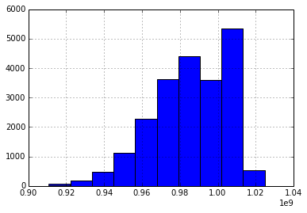

```python
MessageBase.unix_time.hist()
```

```python
MessageBase.unix_time.mean()
```

```
985319365.65994918
```

What does this tell us?

Convert `unix_time` to human readable form (i.e. `datetime`)

`unix_time` (i.e. `unixepoch`) is easy for computers to read, but difficult for humans. It is the number of seconds since midnight, January 1, 1970. To make it more readable, we will map datetime.fromtimestamp onto that value to return a datetime object. We can then downsample the data from seconds to weeks.

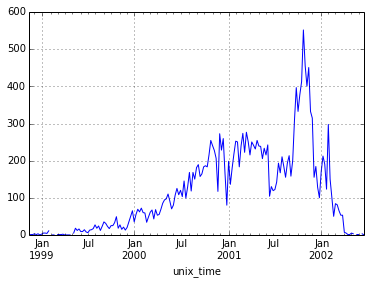

```python
from datetime import datetime
dt = MessageBase.unix_time.map(datetime.fromtimestamp)
MessageBase.groupby(dt).unix_time.count().resample('1W', how='sum').plot()
```

What does this tell us?

Consider recipient counts (i.e. `MAX(rno)`)

Perhaps the recipient counts would be interesting as well. This time we will cast `unix_time` to a datetime string in our query. Since this is a new query, we will also make sure it looks okay by calling `.head()` before we do anyting else:

```python
recipient_counts = sql.frame_query("""SELECT mid, datetime(unix_time, 'unixepoch') AS time_sent,
                                             MAX(rno) AS recipient_count
                                        FROM MessageBase JOIN RecipientBase USING (mid)
                                       GROUP BY mid, time_sent""",
                                   conn, "mid")
recipient_counts.head()
```

| mid | time_sent | recipient_count |
| --- | --- | --- |
| 1 | 1998-11-13 04:07:00 | 1 |
| 2 | 1998-11-19 07:19:00 | 1 |
| 3 | 1998-11-19 08:24:00 | 1 |
| 4 | 1998-11-24 02:23:00 | 4 |
| 5 | 1998-11-30 03:22:00 | 2 |

5 rows × 2 columns

grouping objects

When using `pandas.DataFrame.groupby` it is sometimes useful to create a grouping object first. In this case, we will do it by mapping the datetime strings we received from SQLite to a weekly period. (This could also have been done in SQL, but it would have come across as a string. This way it exists as a `pandas.Period` object which has more intelligence.)

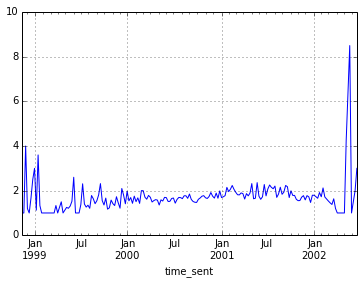

```python
w = recipient_counts.time_sent.map(lambda dt: pd.Period(dt, freq='W'))
recipient_counts.groupby(w).recipient_count.mean().plot(ylim=(0,10))
```

# Lab

## 1-2 Pairs

Raise two fingers if you understand the material well.  
Raise one finger if you understand this material OK.  
Now, 1 find a 2 and sit next to them. While you work through this exercise, only 1's can type.

Use [`matplotlib.pyplot.scatter`](http://matplotlib.org/api/pyplot_api.html#matplotlib.pyplot.scatter) (or `plt.scatter` for short) to plot the length of the `subject`s against the `recipient_count`.

Hint: Take advantage of IPython's help functionality:

```python
import matplotlib.pyplot as plt
plt.scatter?
```

## Individually:

Plot the `median` `subject` `len`gth over time (using the same weekly grouping object above)

Further exercises: Try to find your own discoveries! (e.g. is there anything interesting you could say about the subjects of the emails. What about who sent the first ones and who sent the last ones? What about the recipients themselves? (hint: `to_eid` is a foreign key to `eid`)

See [Pandas for SQL Developers](http://nbviewer.ipython.org/urls/bitbucket.org/hrojas/learn-pandas/raw/master/lessons/Pandas%20for%20SQL%20Developers.ipynb) for more examples about how Pandas and SQL compare.

# Next Time: